# Applied Machine Learning Capstone Project

## Bike Rental Demand Prediction Using Machine Learning

**Team Members:**

- Dhriti Das (B9)
- Drishti Sharma (B10)

**Project Type:** Regression

**Dataset:** UCI Bike Sharing Dataset

### Objective

The objective of this project is to predict the total number of bikes rented per hour using machine learning regression algorithms. The model considers factors such as season, temperature, humidity, weather conditions, working day, and hour of the day.

### Problem Statement

Accurate bike rental demand prediction can help bike-sharing services manage bicycle availability and improve resource allocation.

### Technologies Used

- Python
- Pandas
- NumPy
- Matplotlib
- Scikit-learn
- UCI Machine Learning Repository

## 1. Importing Required Libraries

In this section, we import the necessary Python libraries for data manipulation, numerical operations, visualization, machine learning model development, and performance evaluation.

```python
import pandas as pd
import numpy as np
import matplotlib.pyplot as plt

from ucimlrepo import fetch_ucirepo

from sklearn.model_selection import train_test_split
from sklearn.linear_model import LinearRegression
from sklearn.tree import DecisionTreeRegressor
from sklearn.ensemble import RandomForestRegressor
from sklearn.ensemble import GradientBoostingRegressor

from sklearn.metrics import (
    mean_absolute_error,
    mean_squared_error,
    r2_score
)
```

## 2. Loading the Dataset

In this section, we load the UCI Bike Sharing Dataset directly using the `ucimlrepo` Python library.

Instead of manually downloading the dataset, we fetch it programmatically using its UCI dataset ID (275).

The dataset contains hourly bike rental records along with corresponding weather and seasonal information.

```python
# Fetch Bike Sharing Dataset from UCI
bike_sharing = fetch_ucirepo(id=275)

# Extract features and target
X = bike_sharing.data.features.copy()
y = bike_sharing.data.targets.copy()

# Combine features and target
df = pd.concat([X, y], axis=1)

print("Dataset loaded successfully!")
print("Dataset Shape:", df.shape)
print("Total Records:", len(df))

display(df.head())
```

```
Dataset loaded successfully!
Dataset Shape: (17379, 14)
Total Records: 17379
```

|  | dteday | season | yr | mnth | hr | holiday | weekday | workingday | weathersit | temp | atemp | hum | windspeed | cnt |
| --- | --- | --- | --- | --- | --- | --- | --- | --- | --- | --- | --- | --- | --- | --- |
| 0 | 2011-01-01 | 1 | 0 | 1 | 0 | 0 | 6 | 0 | 1 | 0.24 | 0.2879 | 0.81 | 0.0 | 16 |
| 1 | 2011-01-01 | 1 | 0 | 1 | 1 | 0 | 6 | 0 | 1 | 0.22 | 0.2727 | 0.80 | 0.0 | 40 |
| 2 | 2011-01-01 | 1 | 0 | 1 | 2 | 0 | 6 | 0 | 1 | 0.22 | 0.2727 | 0.80 | 0.0 | 32 |
| 3 | 2011-01-01 | 1 | 0 | 1 | 3 | 0 | 6 | 0 | 1 | 0.24 | 0.2879 | 0.75 | 0.0 | 13 |
| 4 | 2011-01-01 | 1 | 0 | 1 | 4 | 0 | 6 | 0 | 1 | 0.24 | 0.2879 | 0.75 | 0.0 | 1 |

## 3. Understanding the Dataset

Dataset understanding is an important step before applying machine learning algorithms.

In this section, we examine:

- Column names
- Number of records and features
- Data types
- Statistical summary

This helps us understand the structure and characteristics of the dataset.

```python
print("Column Names:")
print(df.columns.tolist())

print("\nDataset Information:")
df.info()

print("\nStatistical Summary:")
display(df.describe())
```

```
Column Names:
['dteday', 'season', 'yr', 'mnth', 'hr', 'holiday', 'weekday', 'workingday', 'weathersit', 'temp', 'atemp', 'hum', 'windspeed', 'cnt']

Dataset Information:
<class 'pandas.DataFrame'>
RangeIndex: 17379 entries, 0 to 17378
Data columns (total 14 columns):
 #   Column      Non-Null Count  Dtype
---  ------      --------------  -----
 0   dteday      17379 non-null  str
 1   season      17379 non-null  int64
 2   yr          17379 non-null  int64
 3   mnth        17379 non-null  int64
 4   hr          17379 non-null  int64
 5   holiday     17379 non-null  int64
 6   weekday     17379 non-null  int64
 7   workingday  17379 non-null  int64
 8   weathersit  17379 non-null  int64
 9   temp        17379 non-null  float64
 10  atemp       17379 non-null  float64
 11  hum         17379 non-null  float64
 12  windspeed   17379 non-null  float64
 13  cnt         17379 non-null  int64
dtypes: float64(4), int64(9), str(1)
memory usage: 1.9 MB

Statistical Summary:
```

|  | season | yr | mnth | hr | holiday | weekday | workingday | weathersit | temp | atemp | hum | windspeed | cnt |
| --- | --- | --- | --- | --- | --- | --- | --- | --- | --- | --- | --- | --- | --- |
| count | 17379.000000 | 17379.000000 | 17379.000000 | 17379.000000 | 17379.000000 | 17379.000000 | 17379.000000 | 17379.000000 | 17379.000000 | 17379.000000 | 17379.000000 | 17379.000000 | 17379.000000 |
| mean | 2.501640 | 0.502561 | 6.537775 | 11.546752 | 0.028770 | 3.003683 | 0.682721 | 1.425283 | 0.496987 | 0.475775 | 0.627229 | 0.190098 | 189.463088 |
| std | 1.106918 | 0.500008 | 3.438776 | 6.914405 | 0.167165 | 2.005771 | 0.465431 | 0.639357 | 0.192556 | 0.171850 | 0.192930 | 0.122340 | 181.387599 |
| min | 1.000000 | 0.000000 | 1.000000 | 0.000000 | 0.000000 | 0.000000 | 0.000000 | 1.000000 | 0.020000 | 0.000000 | 0.000000 | 0.000000 | 1.000000 |
| 25% | 2.000000 | 0.000000 | 4.000000 | 6.000000 | 0.000000 | 1.000000 | 0.000000 | 1.000000 | 0.340000 | 0.333300 | 0.480000 | 0.104500 | 40.000000 |
| 50% | 3.000000 | 1.000000 | 7.000000 | 12.000000 | 0.000000 | 3.000000 | 1.000000 | 1.000000 | 0.500000 | 0.484800 | 0.630000 | 0.194000 | 142.000000 |
| 75% | 3.000000 | 1.000000 | 10.000000 | 18.000000 | 0.000000 | 5.000000 | 1.000000 | 2.000000 | 0.660000 | 0.621200 | 0.780000 | 0.253700 | 281.000000 |
| max | 4.000000 | 1.000000 | 12.000000 | 23.000000 | 1.000000 | 6.000000 | 1.000000 | 4.000000 | 1.000000 | 1.000000 | 1.000000 | 0.850700 | 977.000000 |

## 4. Data Cleaning

Data cleaning helps identify missing values and duplicate records.

Missing values can affect model performance, while duplicate records may introduce unwanted repetition into the dataset.

Therefore, we check both before proceeding with exploratory data analysis.

```python
print("Missing Values in Each Column:")
print(df.isnull().sum())

print("\nNumber of Duplicate Rows:")
print(df.duplicated().sum())
```

```
Missing Values in Each Column:
dteday        0
season        0
yr            0
mnth          0
hr            0
holiday       0
weekday       0
workingday    0
weathersit    0
temp          0
atemp         0
hum           0
windspeed     0
cnt           0
dtype: int64

Number of Duplicate Rows:
0
```

## 5. Exploratory Data Analysis (EDA)

Exploratory Data Analysis helps us understand patterns, distributions, and relationships within the dataset.

In this section, we visualize:

1. Distribution of bike rental demand.
2. Average bike rentals according to the hour of the day.
3. Average bike rentals according to weather conditions.

These visualizations help identify factors that may influence bike rental demand.

### 5.1 Distribution of Bike Rental Demand

A histogram is used to visualize the distribution of total hourly bike rentals.

It helps us understand how frequently different rental demand levels occur.

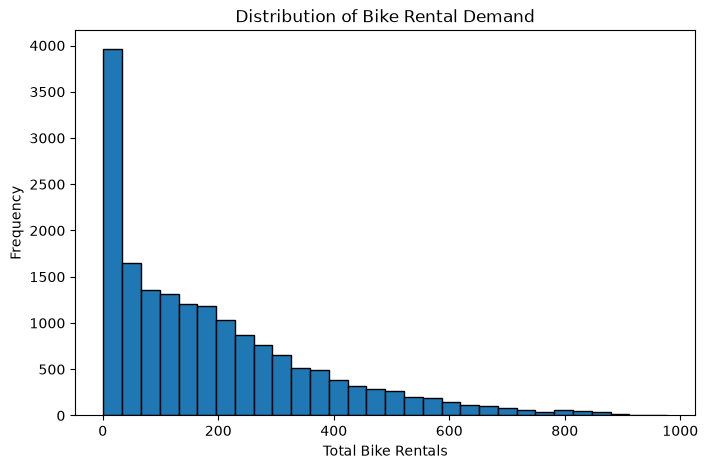

```python
plt.figure(figsize=(8, 5))

plt.hist(df["cnt"], bins=30, edgecolor="black")

plt.xlabel("Total Bike Rentals")
plt.ylabel("Frequency")
plt.title("Distribution of Bike Rental Demand")

plt.show()
```

### 5.2 Average Bike Rental Demand by Hour

A line graph is used to analyze how bike rental demand changes throughout the day.

This helps identify hours with higher and lower average rental activity.

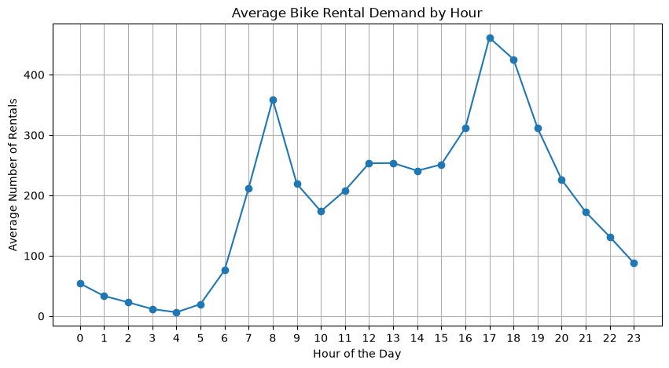

```python
hourly_demand = df.groupby("hr")["cnt"].mean()

plt.figure(figsize=(10, 5))

plt.plot(
    hourly_demand.index,
    hourly_demand.values,
    marker="o"
)

plt.xlabel("Hour of the Day")
plt.ylabel("Average Number of Rentals")
plt.title("Average Bike Rental Demand by Hour")

plt.xticks(range(24))
plt.grid(True)

plt.show()
```

### 5.3 Average Bike Rentals by Weather Situation

Weather conditions can influence people's willingness to use rental bicycles.

A bar chart is used to compare average bike rentals across different weather situations.

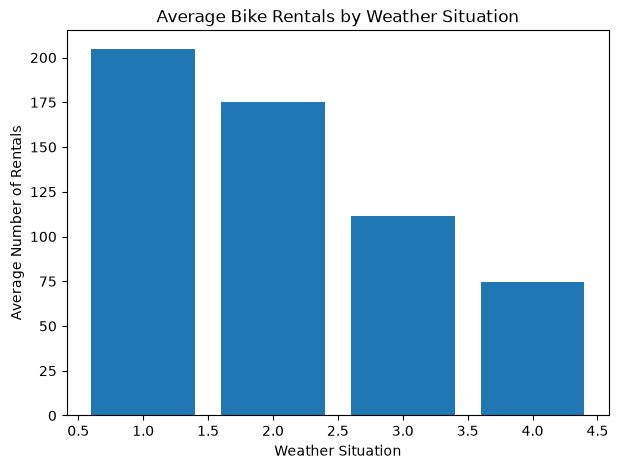

```python
weather_demand = df.groupby("weathersit")["cnt"].mean()

plt.figure(figsize=(7, 5))

plt.bar(
    weather_demand.index,
    weather_demand.values
)

plt.xlabel("Weather Situation")
plt.ylabel("Average Number of Rentals")
plt.title("Average Bike Rentals by Weather Situation")

plt.show()
```

## 6. Data Preprocessing

Data preprocessing is an important step in machine learning that prepares the dataset for model training.

In this project, the target variable is `cnt`, which represents the total number of bikes rented.

We remove unnecessary columns such as:

- `instant`: Record index.
- `dteday`: Date information.
- `casual`: Number of casual users.
- `registered`: Number of registered users.

The columns `casual` and `registered` are removed because their sum directly represents the target variable `cnt`. Keeping them would cause target leakage.

The remaining relevant features are used as input variables for predicting bike rental demand.

```python
# Remove unnecessary columns

X = df.drop(
    columns=[
        "cnt",
        "casual",
        "registered",
        "instant",
        "dteday"
    ],
    errors="ignore"
)

# Define target variable
y = df["cnt"]

print("Input Features:")
print(X.columns.tolist())

print("\nNumber of Input Features:", X.shape[1])
print("Target Variable: cnt")

print("\nFeature Shape:", X.shape)
print("Target Shape:", y.shape)
```

```
Input Features:
['season', 'yr', 'mnth', 'hr', 'holiday', 'weekday', 'workingday', 'weathersit', 'temp', 'atemp', 'hum', 'windspeed']

Number of Input Features: 12
Target Variable: cnt

Feature Shape: (17379, 12)
Target Shape: (17379,)
```

## 7. Splitting the Dataset

The dataset is divided into training and testing sets using the train_test_split function.

- Training Set: 80% of the dataset.
- Testing Set: 20% of the dataset.
- Random State: 42.

The training dataset is used to train the machine learning models, while the testing dataset is used to evaluate their performance on unseen data.

This helps us understand how well the models can predict bike rental demand.

```python
X_train, X_test, y_train, y_test = train_test_split(
    X,
    y,
    test_size=0.2,
    random_state=42
)

print("Training Features:", X_train.shape)
print("Testing Features:", X_test.shape)

print("Training Target:", y_train.shape)
print("Testing Target:", y_test.shape)
```

```
Training Features: (13903, 12)
Testing Features: (3476, 12)
Training Target: (13903,)
Testing Target: (3476,)
```

## 8. Model Training

In this section, we train four different machine learning regression algorithms to predict hourly bike rental demand.

The algorithms used are:

1. Linear Regression
2. Decision Tree Regressor
3. Random Forest Regressor
4. Gradient Boosting Regressor

Each model learns patterns from the training dataset and predicts the number of bikes rented based on the input features.

```python
# Define regression models

models = {
    "Linear Regression": LinearRegression(),

    "Decision Tree": DecisionTreeRegressor(
        random_state=42,
        max_depth=15
    ),

    "Random Forest": RandomForestRegressor(
        n_estimators=100,
        random_state=42,
        n_jobs=-1
    ),

    "Gradient Boosting": GradientBoostingRegressor(
        n_estimators=100,
        random_state=42
    )
}

results = []
trained_models = {}

# Train all models
for name, model in models.items():

    model.fit(X_train, y_train)

    y_pred = model.predict(X_test)

    mae = mean_absolute_error(y_test, y_pred)
    mse = mean_squared_error(y_test, y_pred)
    rmse = np.sqrt(mse)
    r2 = r2_score(y_test, y_pred)

    results.append({
        "Model": name,
        "MAE": mae,
        "MSE": mse,
        "RMSE": rmse,
        "R2 Score": r2
    })

    trained_models[name] = model

    print(name, "trained successfully!")

print("\nAll models trained successfully!")
```

```
Linear Regression trained successfully!
Decision Tree trained successfully!
Random Forest trained successfully!
Gradient Boosting trained successfully!

All models trained successfully!
```

## 9. Model Evaluation

After training the four regression models, we evaluate their performance using the following evaluation metrics:

1. **Mean Absolute Error (MAE):** Measures the average absolute difference between actual and predicted values.
2. **Mean Squared Error (MSE):** Measures the average squared difference between actual and predicted values.
3. **Root Mean Squared Error (RMSE):** Represents the square root of MSE and indicates prediction error in the original unit.
4. **R² Score:** Measures how well the model explains the variation in bike rental demand.

Lower MAE, MSE, and RMSE values indicate better performance, while a higher R² score indicates a better model.

```python
results_df = pd.DataFrame(results)

print("Model Evaluation Results:\n")
display(results_df.round(3))
```

```
Model Evaluation Results:
```

|  | Model | MAE | MSE | RMSE | R2 Score |
| --- | --- | --- | --- | --- | --- |
| 0 | Linear Regression | 104.803 | 19379.828 | 139.211 | 0.388 |
| 1 | Decision Tree | 33.420 | 3345.219 | 57.838 | 0.894 |
| 2 | Random Forest | 24.903 | 1769.836 | 42.069 | 0.944 |
| 3 | Gradient Boosting | 47.149 | 4766.556 | 69.040 | 0.849 |

## 10. Model Comparison

In this section, we compare the performance of all four regression models using their MAE, MSE, RMSE, and R² scores.

Visual comparison helps identify which algorithm performs better for predicting bike rental demand.

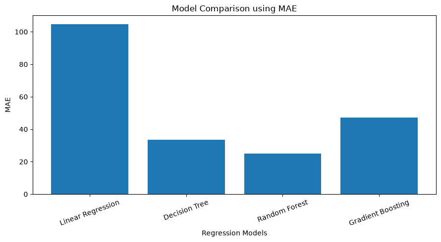

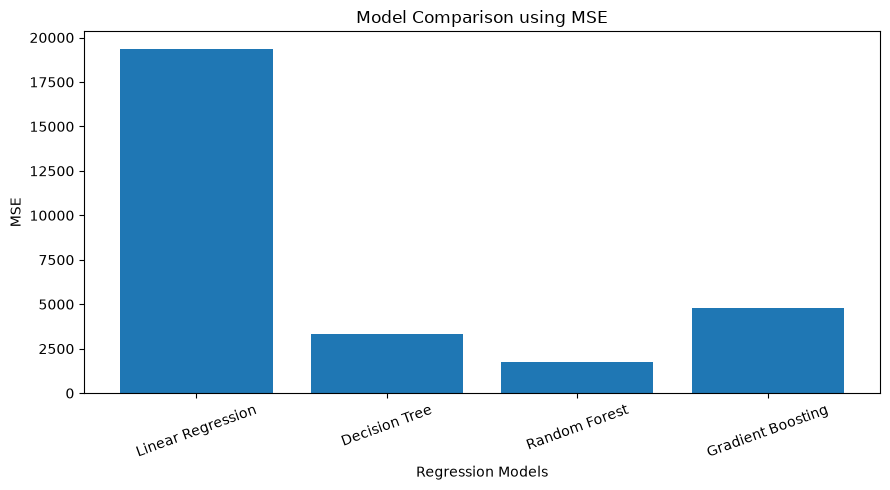

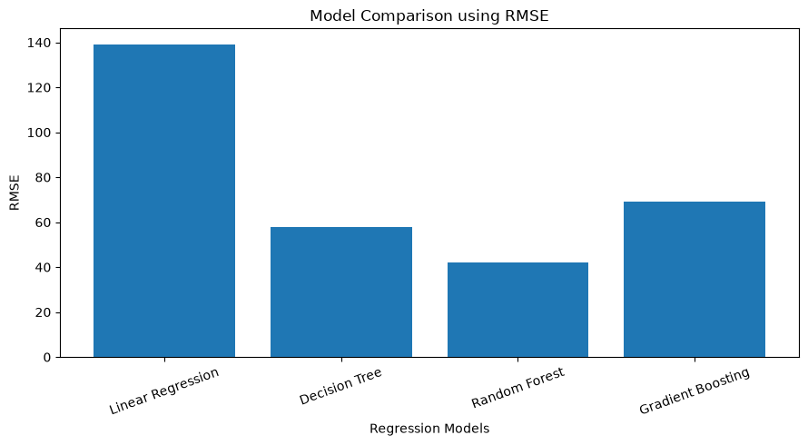

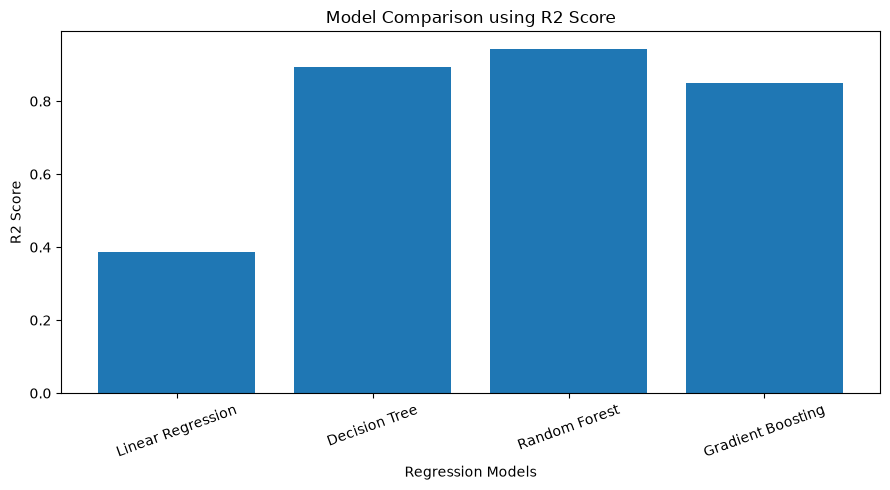

```python
metrics = ["MAE", "MSE", "RMSE", "R2 Score"]

for metric in metrics:
    plt.figure(figsize=(9, 5))

    plt.bar(
        results_df["Model"],
        results_df[metric]
    )

    plt.xlabel("Regression Models")
    plt.ylabel(metric)
    plt.title(f"Model Comparison using {metric}")
    plt.xticks(rotation=20)
    plt.tight_layout()
    plt.show()
```

## 11. Selection of the Best Model

The best regression model is selected based on its evaluation metrics.

A model with lower prediction errors and a higher R² score is considered more suitable for predicting bike rental demand.

```python
best_model_row = results_df.sort_values(
    by="R2 Score",
    ascending=False
).iloc[0]

best_model_name = best_model_row["Model"]
best_model = trained_models[best_model_name]

print("Best Model:", best_model_name)
print("\nBest Model Performance:")
print(best_model_row)
```

```
Best Model: Random Forest

Best Model Performance:
Model       Random Forest
MAE             24.902862
MSE           1769.836445
RMSE            42.069424
R2 Score         0.944108
Name: 2, dtype: object
```

## 12. Feature Importance

Feature importance helps us understand which input variables contribute most to predicting bike rental demand.

We use the feature importance values from the trained Decision Tree, Random Forest, and Gradient Boosting models to identify important features.

```
Feature Importance - Decision Tree
```

|  | Feature | Importance |
| --- | --- | --- |
| 3 | hr | 0.617409 |
| 8 | temp | 0.114823 |
| 1 | yr | 0.081759 |
| 6 | workingday | 0.062675 |
| 10 | hum | 0.025636 |
| 0 | season | 0.023853 |
| 9 | atemp | 0.020015 |
| 7 | weathersit | 0.017168 |
| 2 | mnth | 0.015363 |
| 5 | weekday | 0.010415 |
| 11 | windspeed | 0.008105 |
| 4 | holiday | 0.002779 |

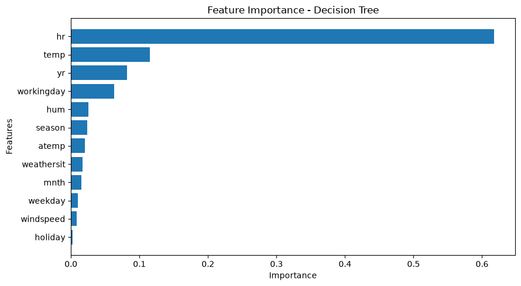

```
Feature Importance - Random Forest
```

|  | Feature | Importance |
| --- | --- | --- |
| 3 | hr | 0.612154 |
| 8 | temp | 0.118983 |
| 1 | yr | 0.080795 |
| 6 | workingday | 0.057764 |
| 10 | hum | 0.026793 |
| 9 | atemp | 0.021805 |
| 0 | season | 0.021733 |
| 7 | weathersit | 0.018221 |
| 2 | mnth | 0.016530 |
| 5 | weekday | 0.012411 |
| 11 | windspeed | 0.010270 |
| 4 | holiday | 0.002541 |

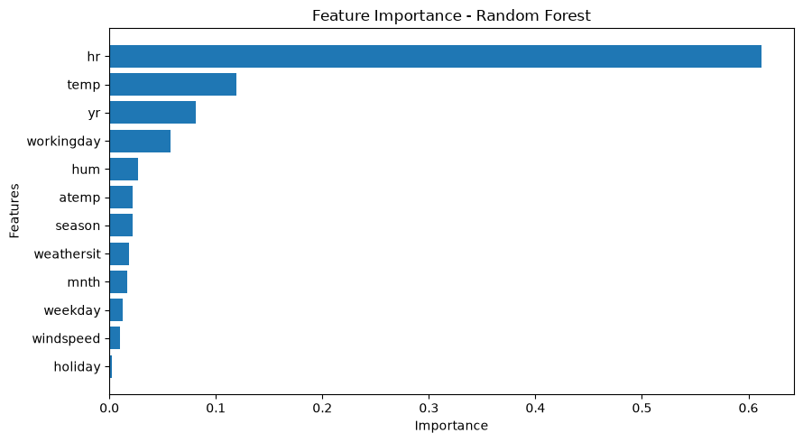

```
Feature Importance - Gradient Boosting
```

|  | Feature | Importance |
| --- | --- | --- |
| 3 | hr | 0.626849 |
| 8 | temp | 0.094126 |
| 1 | yr | 0.091132 |
| 6 | workingday | 0.080701 |
| 9 | atemp | 0.045855 |
| 0 | season | 0.024797 |
| 10 | hum | 0.012752 |
| 7 | weathersit | 0.012442 |
| 2 | mnth | 0.006244 |
| 5 | weekday | 0.003594 |
| 11 | windspeed | 0.001209 |
| 4 | holiday | 0.000299 |

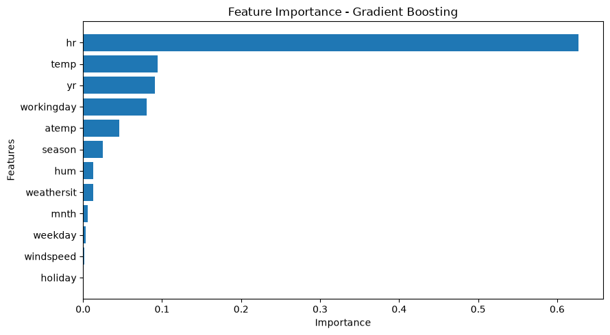

```python
feature_models = [
    "Decision Tree",
    "Random Forest",
    "Gradient Boosting"
]

for model_name in feature_models:
    model = trained_models[model_name]

    importance_df = pd.DataFrame({
        "Feature": X.columns,
        "Importance": model.feature_importances_
    })

    importance_df = importance_df.sort_values(
        by="Importance",
        ascending=False
    )

    print("\nFeature Importance -", model_name)
    display(importance_df)

    plt.figure(figsize=(9, 5))
    plt.barh(
        importance_df["Feature"],
        importance_df["Importance"]
    )
    plt.xlabel("Importance")
    plt.ylabel("Features")
    plt.title(f"Feature Importance - {model_name}")
    plt.gca().invert_yaxis()
    plt.tight_layout()
    plt.show()
```

## 13. Actual vs Predicted Values

This section compares the actual bike rental counts with the values predicted by the selected best-performing model.

A scatter plot is used to visualize how closely the predicted values match the actual values.

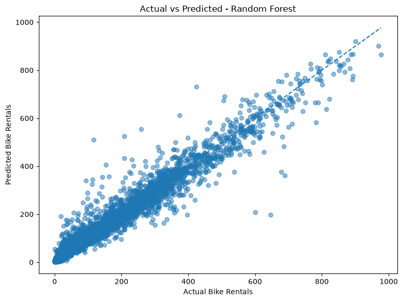

```python
best_predictions = best_model.predict(X_test)

plt.figure(figsize=(8, 6))

plt.scatter(
    y_test,
    best_predictions,
    alpha=0.5
)

plt.xlabel("Actual Bike Rentals")
plt.ylabel("Predicted Bike Rentals")
plt.title(f"Actual vs Predicted - {best_model_name}")

min_value = min(y_test.min(), best_predictions.min())
max_value = max(y_test.max(), best_predictions.max())

plt.plot(
    [min_value, max_value],
    [min_value, max_value],
    linestyle="--"
)

plt.tight_layout()
plt.show()
```

## 14. Sample Predictions

In this section, we display a few actual and predicted bike rental values to understand the prediction performance of the selected model.

```python
sample_predictions = pd.DataFrame({
    "Actual Rentals": y_test.iloc[:10].values,
    "Predicted Rentals": best_predictions[:10]
})

sample_predictions["Predicted Rentals"] = (
    sample_predictions["Predicted Rentals"].round(0).astype(int)
)

display(sample_predictions)
```

|  | Actual Rentals | Predicted Rentals |
| --- | --- | --- |
| 0 | 425 | 381 |
| 1 | 88 | 96 |
| 2 | 4 | 12 |
| 3 | 526 | 542 |
| 4 | 13 | 15 |
| 5 | 32 | 40 |
| 6 | 706 | 743 |
| 7 | 26 | 37 |
| 8 | 2 | 10 |
| 9 | 21 | 26 |

## 15. Conclusion

This project focused on predicting hourly bike rental demand using four machine learning regression algorithms: Linear Regression, Decision Tree, Random Forest, and Gradient Boosting.

Among the four models, Random Forest performed the best with an R² score of 0.9441 (94.41%), MAE of 24.90, and RMSE of 42.07.

The feature importance analysis showed that hour of the day (hr) was the most influential feature in predicting bike rental demand.

The project demonstrates how machine learning can help bike-sharing services predict rental demand, improve bicycle availability, and support efficient resource allocation.

## 16. References

1. UCI Machine Learning Repository – Bike Sharing Dataset. https://archive.ics.uci.edu/dataset/275/bike+sharing+dataset
2. Scikit-learn Documentation. https://scikit-learn.org/stable/
3. Pandas Documentation. https://pandas.pydata.org/docs/
4. Matplotlib Documentation. https://matplotlib.org/stable/